# morph_FINAL_new

Allison Davis Connelly

12/22/2023

# *Morphological variation of amazon and sailfin mollies*

In this study, I am looking at various populations of amazon and sailfin mollies across their native/introduced range to assess morphological variation both within and among the species. I am using the Pickle fish collections for my samples.

*Data collection*

[output not shown]

## Correcting for body size (residuals)

Since amazons are in general bigger than sailfin, we don’t want any results to be due to this difference in body size bias. Therefore, we will see what traits are influenced by body size (regressions) and correct for body size when necessary (absolute value of residuals). We can then use the residuals when comparing between species for traits that are influenced by body size, and raw data for traits that are not influenced by body size. I will also calculate standardized residuals to compare residuals across traits in later analyses.

### Regressions

- STEP ONE: plot trait vs body size

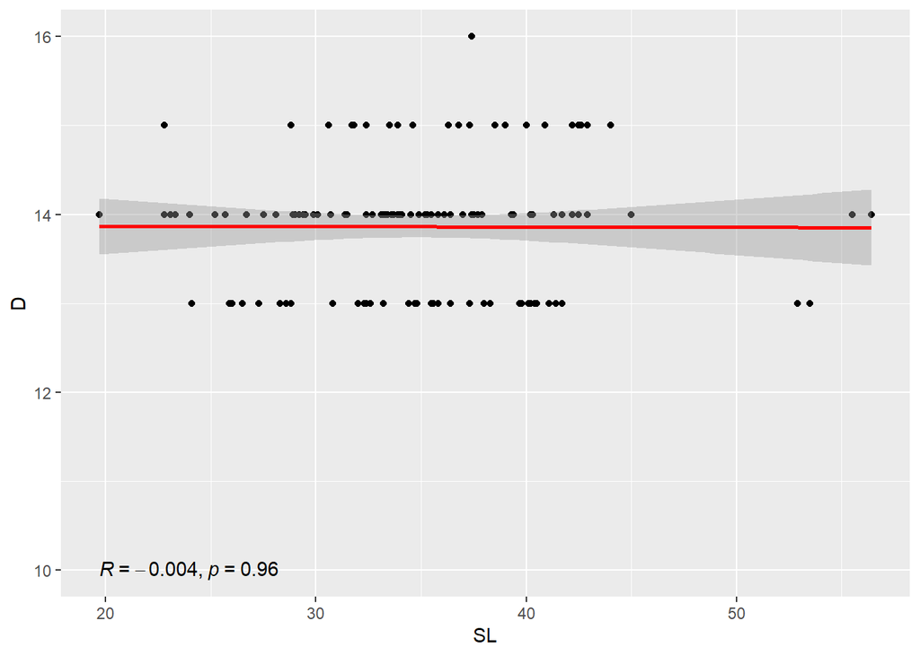

```r
library(ggplot2)
library(ggpubr)

lat1 <- lat[complete.cases(lat[, 15:37]),]
form1 <- form[complete.cases(form[, 15:37]),]
mex1 <- mex[complete.cases(mex[, 15:37]),]

##### LAT #####
reg.lat.D <- lm(lat1$D ~ lat1$SL)
sd.lat.D <- rstandard(reg.lat.D)
reg.lat.D.plot <- ggplot(lat1, aes(x = SL, y = D)) +
  geom_point() +
  stat_smooth(method = "lm", col = "red") +
  stat_cor(label.y = 10)
reg.lat.D.plot
```

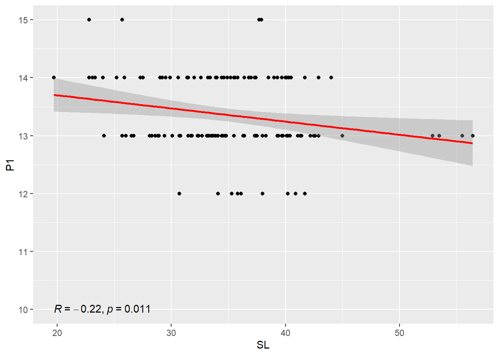

```r
reg.lat.P1 <- lm(lat1$P1 ~ lat1$SL)
sd.lat.P1 <- rstandard(reg.lat.P1)
reg.lat.P1.plot <- ggplot(lat1, aes(x = SL, y = P1)) +
  geom_point() +
  stat_smooth(method = "lm", col = "red") +
  stat_cor(label.y = 10)
reg.lat.P1.plot
```

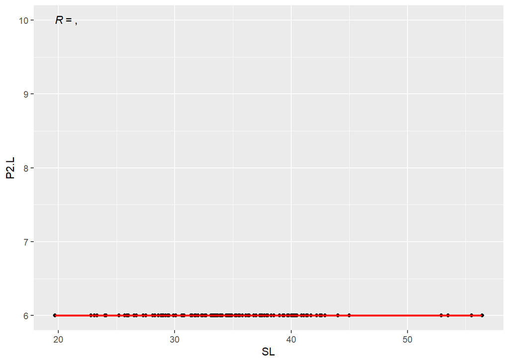

```r
reg.lat.P2.L <- lm(lat1$P2.L ~ lat1$SL)
sd.lat.P2.L <- rstandard(reg.lat.P2.L)
reg.lat.P2.L.plot <- ggplot(lat1, aes(x = SL, y = P2.L)) +
  geom_point() +
  stat_smooth(method = "lm", col = "red") +
  stat_cor(label.y = 10)
reg.lat.P2.L.plot
```

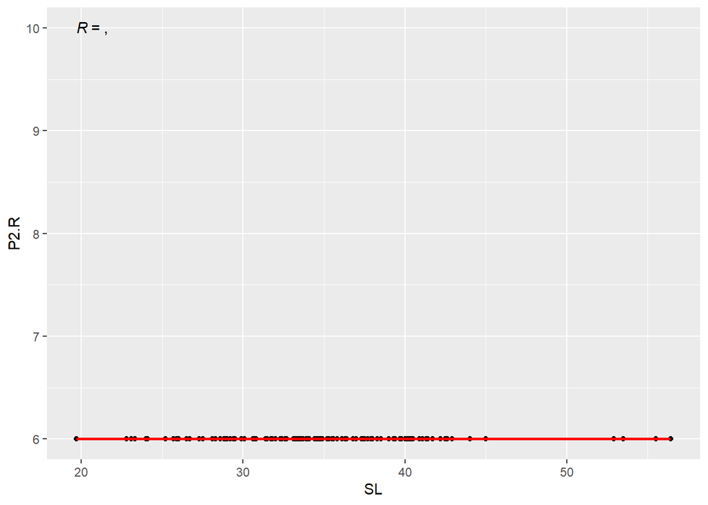

```r
reg.lat.P2.R <- lm(lat1$P2.R ~ lat1$SL)
sd.lat.P2.R <- rstandard(reg.lat.P2.R)
reg.lat.P2.R.plot <- ggplot(lat1, aes(x = SL, y = P2.R)) +
  geom_point() +
  stat_smooth(method = "lm", col = "red") +
  stat_cor(label.y = 10)
reg.lat.P2.R.plot
```

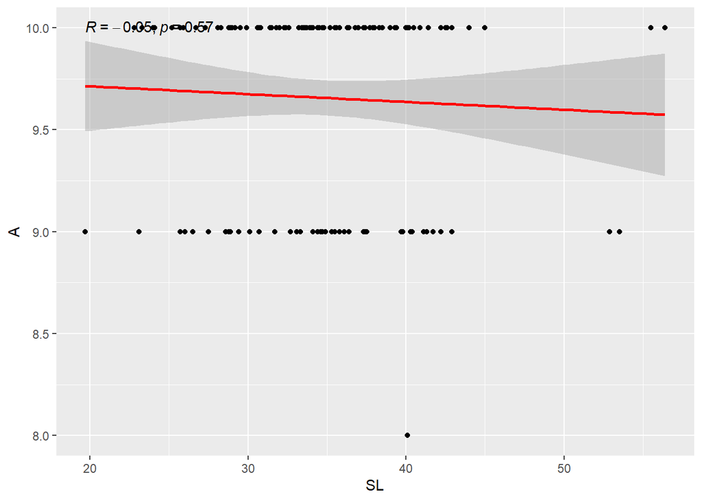

```r
reg.lat.A <- lm(lat1$A ~ lat1$SL)
sd.lat.A <- rstandard(reg.lat.A)
reg.lat.A.plot <- ggplot(lat1, aes(x = SL, y = A)) +
  geom_point() +
  stat_smooth(method = "lm", col = "red") +
  stat_cor(label.y = 10)
reg.lat.A.plot
```

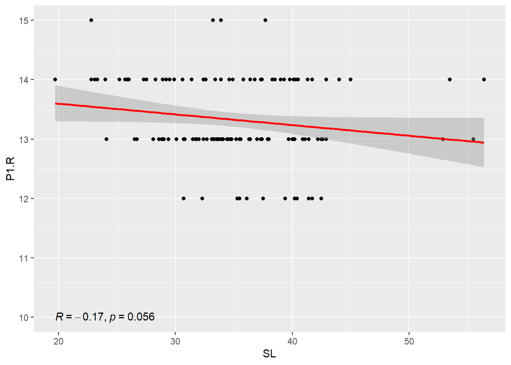

```r
reg.lat.P1.R <- lm(lat1$P1.R ~ lat1$SL)
sd.lat.P1.R <- rstandard(reg.lat.P1.R)
reg.lat.P1.R.plot <- ggplot(lat1, aes(x = SL, y = P1.R)) +
  geom_point() +
  stat_smooth(method = "lm", col = "red") +
  stat_cor(label.y = 10)
reg.lat.P1.R.plot
```

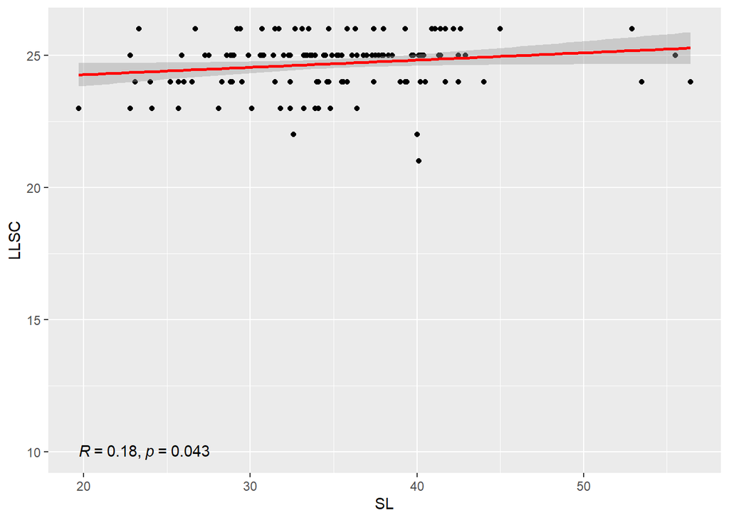

```r
reg.lat.LLSC <- lm(lat1$LLSC ~ lat1$SL)
sd.lat.LLSC <- rstandard(reg.lat.LLSC)
reg.lat.LLSC.plot <- ggplot(lat1, aes(x = SL, y = LLSC)) +
  geom_point() +
  stat_smooth(method = "lm", col = "red") +
  stat_cor(label.y = 10)
reg.lat.LLSC.plot
```

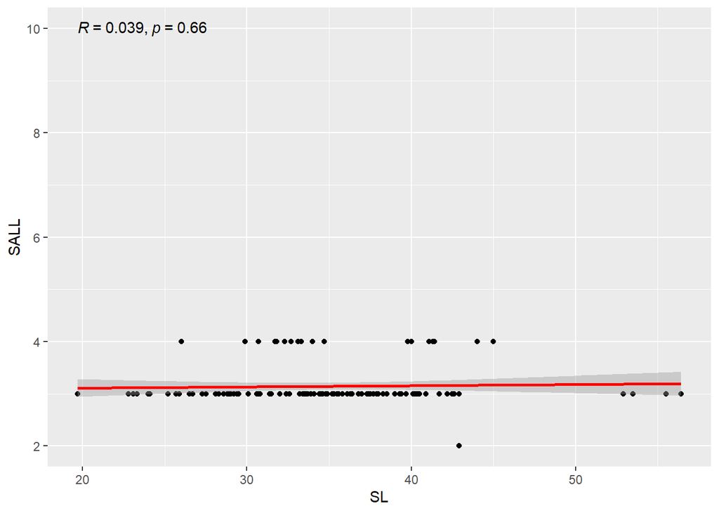

```r
reg.lat.SALL <- lm(lat1$SALL ~ lat1$SL)
sd.lat.SALL <- rstandard(reg.lat.SALL)
reg.lat.SALL.plot <- ggplot(lat1, aes(x = SL, y = SALL)) +
  geom_point() +
  stat_smooth(method = "lm", col = "red") +
  stat_cor(label.y = 10)
reg.lat.SALL.plot
```

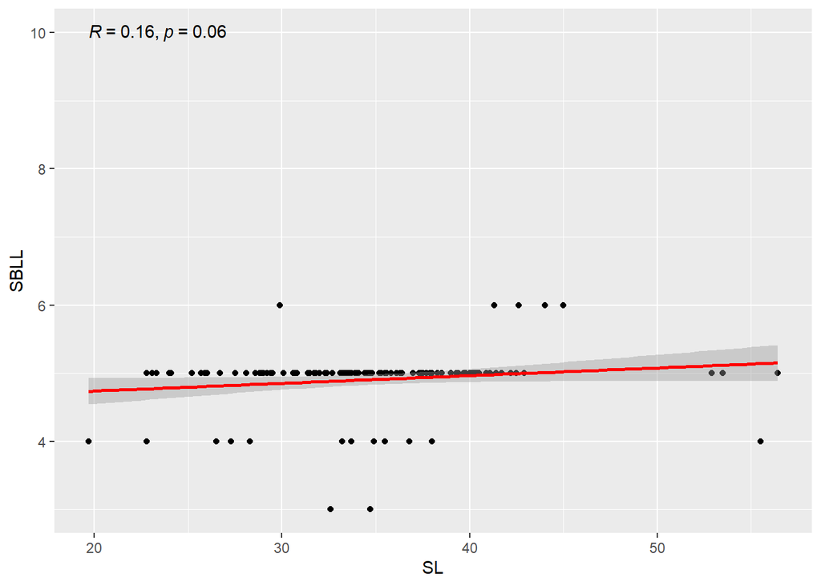

```r
reg.lat.SBLL <- lm(lat1$SBLL ~ lat1$SL)
sd.lat.SBLL <- rstandard(reg.lat.SBLL)
reg.lat.SBLL.plot <- ggplot(lat1, aes(x = SL, y = SBLL)) +
  geom_point() +
  stat_smooth(method = "lm", col = "red") +
  stat_cor(label.y = 10)
reg.lat.SBLL.plot
```

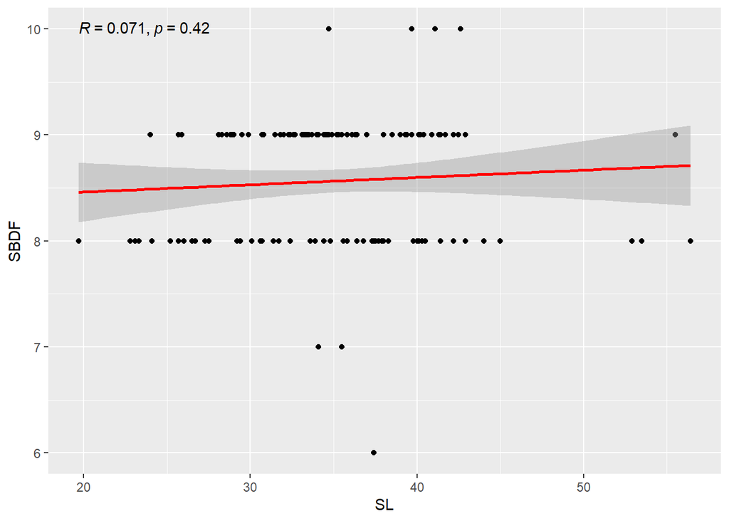

```r
reg.lat.SBDF <- lm(lat1$SBDF ~ lat1$SL)
sd.lat.SBDF <- rstandard(reg.lat.SBDF)
reg.lat.SBDF.plot <- ggplot(lat1, aes(x = SL, y = SBDF)) +
  geom_point() +
  stat_smooth(method = "lm", col = "red") +
  stat_cor(label.y = 10)
reg.lat.SBDF.plot
```

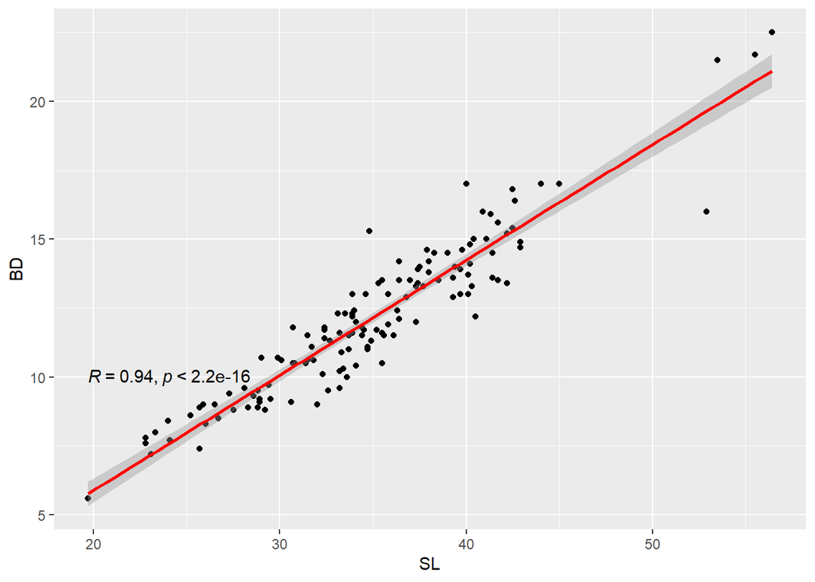

```r
reg.lat.BD <- lm(lat1$BD ~ lat1$SL)
sd.lat.BD <- rstandard(reg.lat.BD)
reg.lat.BD.plot <- ggplot(lat1, aes(x = SL, y = BD)) +
  geom_point() +
  stat_smooth(method = "lm", col = "red") +
  stat_cor(label.y = 10)
reg.lat.BD.plot
```

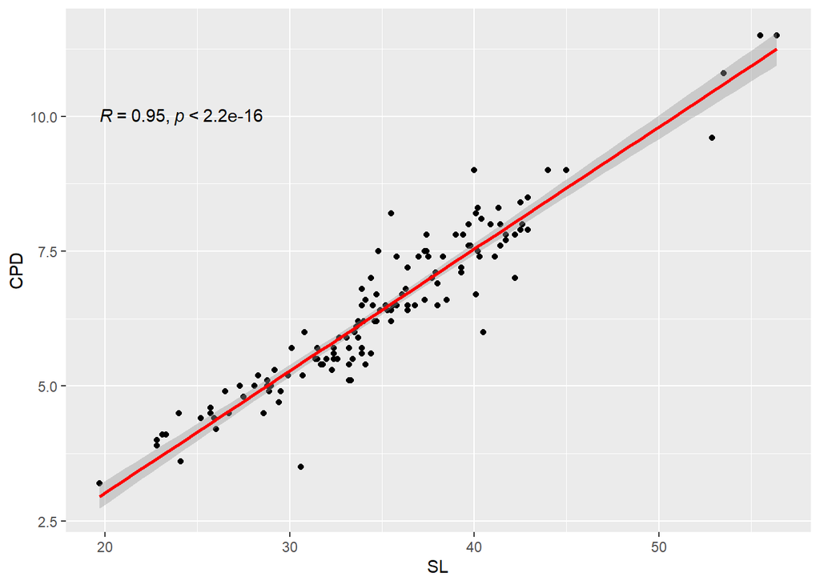

```r
reg.lat.CPD <- lm(lat1$CPD ~ lat1$SL)
sd.lat.CPD <- rstandard(reg.lat.CPD)
reg.lat.CPD.plot <- ggplot(lat1, aes(x = SL, y = CPD)) +
  geom_point() +
  stat_smooth(method = "lm", col = "red") +
  stat_cor(label.y = 10)
reg.lat.CPD.plot
```

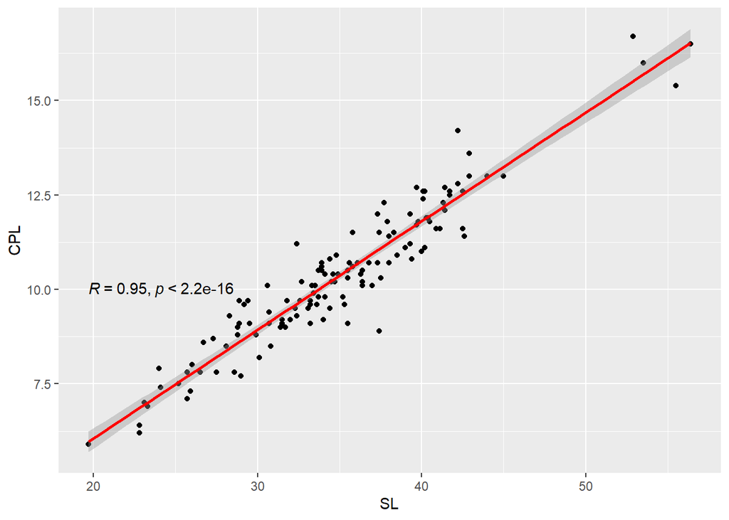

```r
reg.lat.CPL <- lm(lat1$CPL ~ lat1$SL)
sd.lat.CPL <- rstandard(reg.lat.CPL)
reg.lat.CPL.plot <- ggplot(lat1, aes(x = SL, y = CPL)) +
  geom_point() +
  stat_smooth(method = "lm", col = "red") +
  stat_cor(label.y = 10)
reg.lat.CPL.plot
```

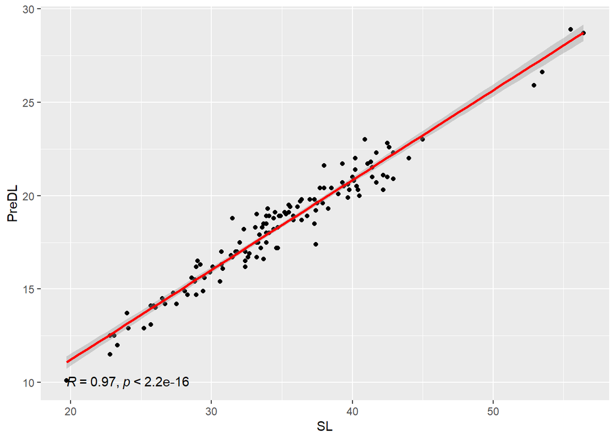

```r
reg.lat.PreDL <- lm(lat1$PreDL ~ lat1$SL)
sd.lat.PreDL <- rstandard(reg.lat.PreDL)
reg.lat.PreDL.plot <- ggplot(lat1, aes(x = SL, y = PreDL)) +
  geom_point() +
  stat_smooth(method = "lm", col = "red") +
  stat_cor(label.y = 10)
reg.lat.PreDL.plot
```

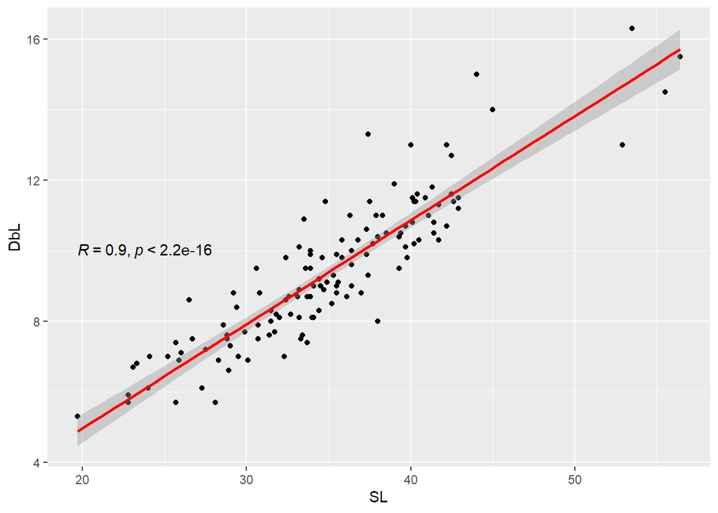

```r
reg.lat.DbL <- lm(lat1$DbL ~ lat1$SL)
sd.lat.DbL <- rstandard(reg.lat.DbL)
reg.lat.DbL.plot <- ggplot(lat1, aes(x = SL, y = DbL)) +
  geom_point() +
  stat_smooth(method = "lm", col = "red") +
  stat_cor(label.y = 10)
reg.lat.DbL.plot
```

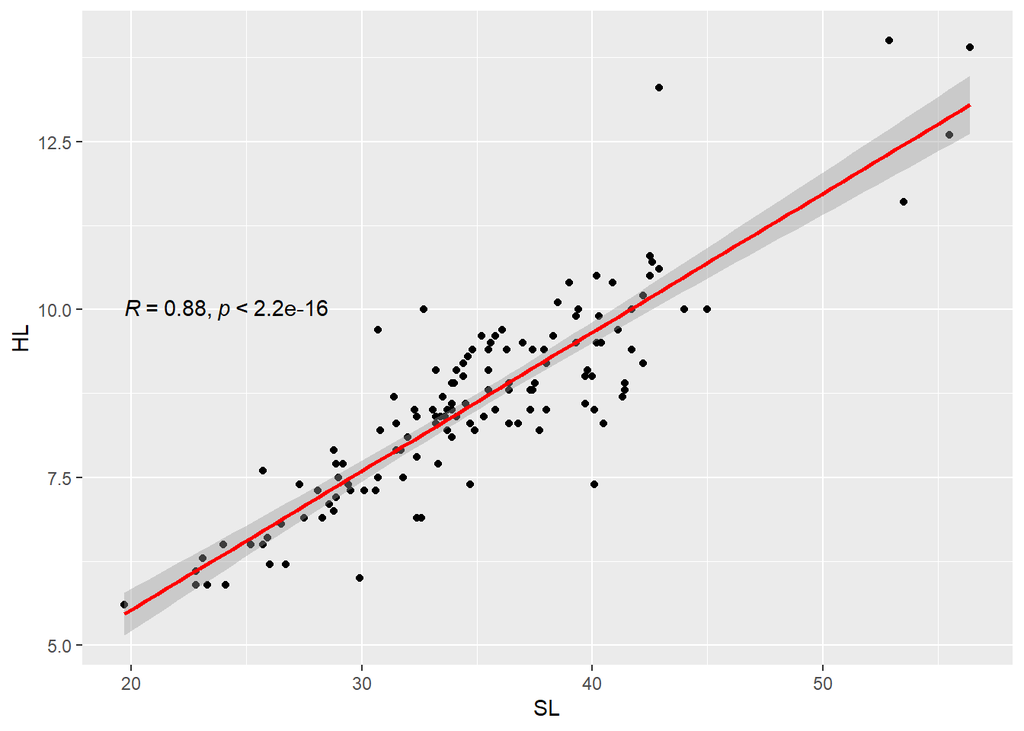

```r
reg.lat.HL <- lm(lat1$HL ~ lat1$SL)
sd.lat.HL <- rstandard(reg.lat.HL)
reg.lat.HL.plot <- ggplot(lat1, aes(x = SL, y = HL)) +
  geom_point() +
  stat_smooth(method = "lm", col = "red") +
  stat_cor(label.y = 10)
reg.lat.HL.plot
```

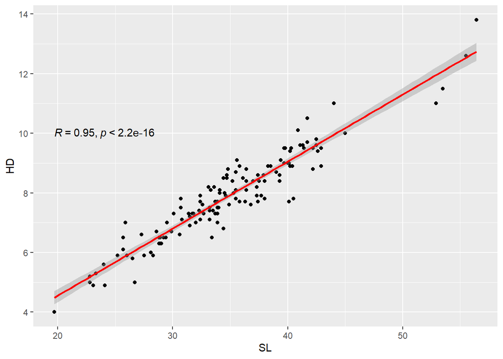

```r
reg.lat.HD <- lm(lat1$HD ~ lat1$SL)
sd.lat.HD <- rstandard(reg.lat.HD)
reg.lat.HD.plot <- ggplot(lat1, aes(x = SL, y = HD)) +
  geom_point() +
  stat_smooth(method = "lm", col = "red") +
  stat_cor(label.y = 10)
reg.lat.HD.plot
```

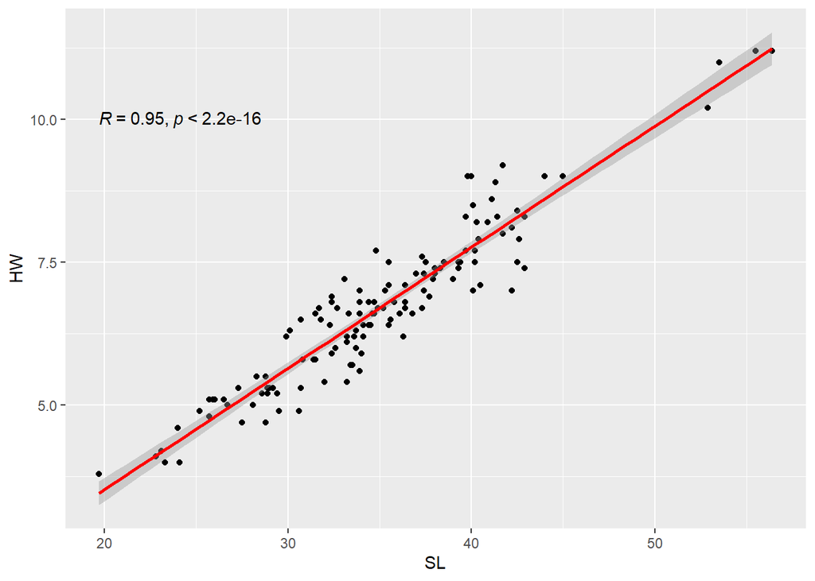

```r
reg.lat.HW <- lm(lat1$HW ~ lat1$SL)
sd.lat.HW <- rstandard(reg.lat.HW)
reg.lat.HW.plot <- ggplot(lat1, aes(x = SL, y = HW)) +
  geom_point() +
  stat_smooth(method = "lm", col = "red") +
  stat_cor(label.y = 10)
reg.lat.HW.plot
```

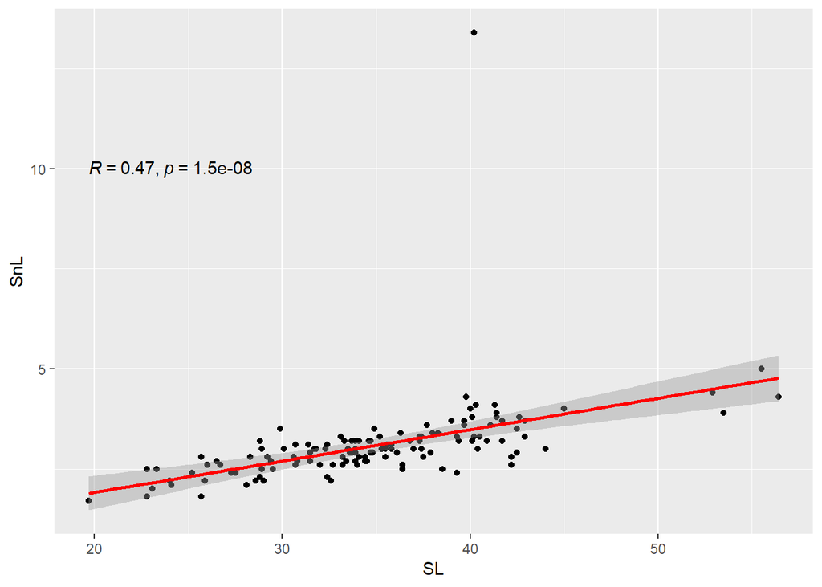

```r
reg.lat.SnL <- lm(lat1$SnL ~ lat1$SL)
sd.lat.SnL <- rstandard(reg.lat.SnL)
reg.lat.SnL.plot <- ggplot(lat1, aes(x = SL, y = SnL)) +
  geom_point() +
  stat_smooth(method = "lm", col = "red") +
  stat_cor(label.y = 10)
reg.lat.SnL.plot
```

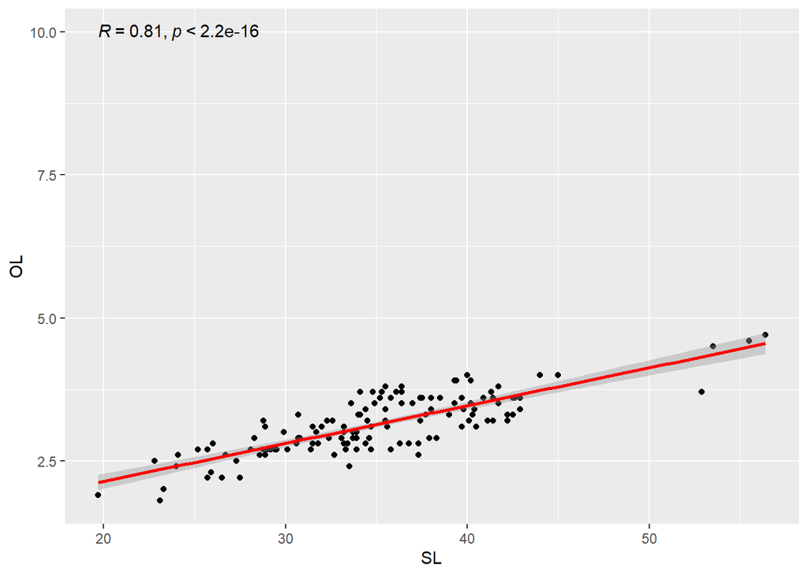

```r
reg.lat.OL <- lm(lat1$OL ~ lat1$SL)
sd.lat.OL <- rstandard(reg.lat.OL)
reg.lat.OL.plot <- ggplot(lat1, aes(x = SL, y = OL)) +
  geom_point() +
  stat_smooth(method = "lm", col = "red") +
  stat_cor(label.y = 10)
reg.lat.OL.plot
```

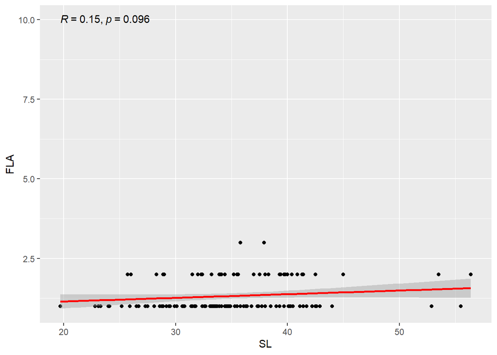

```r
reg.lat.FLA <- lm(lat1$FLA ~ lat1$SL)
sd.lat.FLA <- rstandard(reg.lat.FLA)
reg.lat.FLA.plot <- ggplot(lat1, aes(x = SL, y = FLA)) +
  geom_point() +
  stat_smooth(method = "lm", col = "red") +
  stat_cor(label.y = 10)
reg.lat.FLA.plot
```

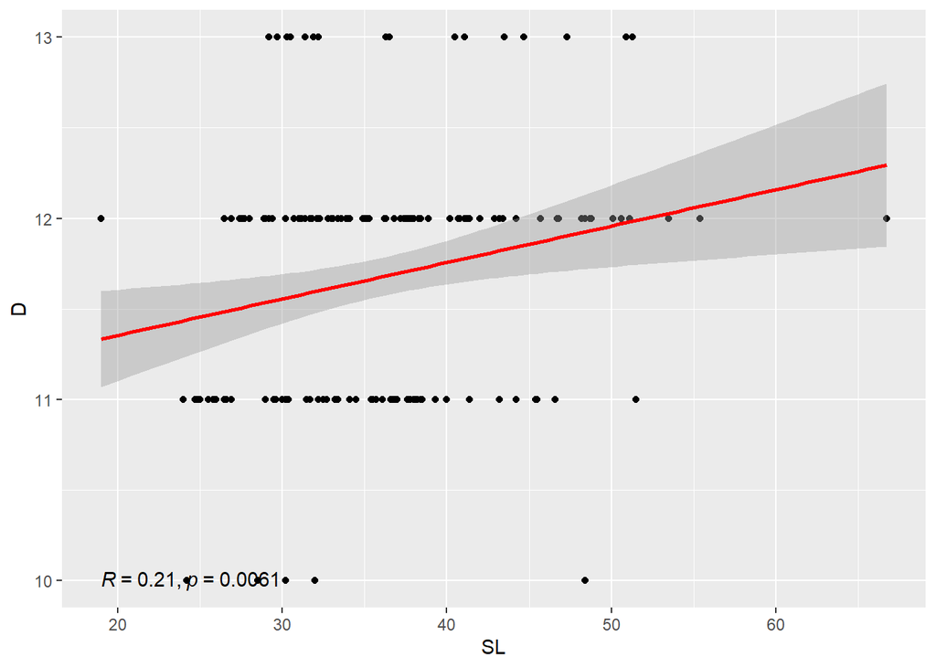

```r
##### FORM #####

reg.form.D <- lm(form1$D ~ form1$SL)
sd.form.D <- rstandard(reg.form.D)
reg.form.D.plot <- ggplot(form1, aes(x =SL, y = D)) +
  geom_point() +
  stat_smooth(method = "lm", col = "red") +
  stat_cor(label.y = 10)
reg.form.D.plot
```

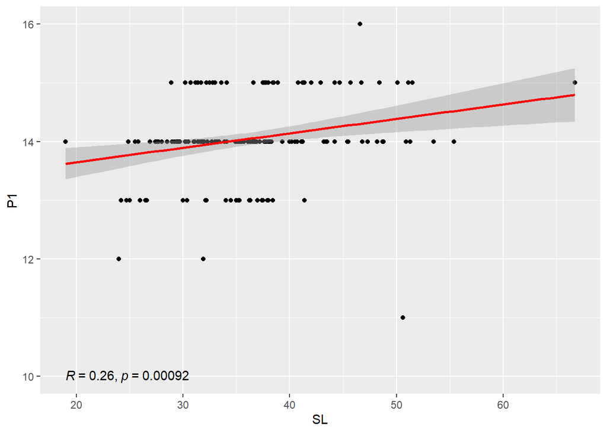

```r
reg.form.P1 <- lm(form1$P1 ~ form1$SL)
sd.form.P1 <- rstandard(reg.form.P1)
reg.form.P1.plot <- ggplot(form1, aes(x = SL, y = P1)) +
  geom_point() +
  stat_smooth(method = "lm", col = "red") +
  stat_cor(label.y = 10)
reg.form.P1.plot
```

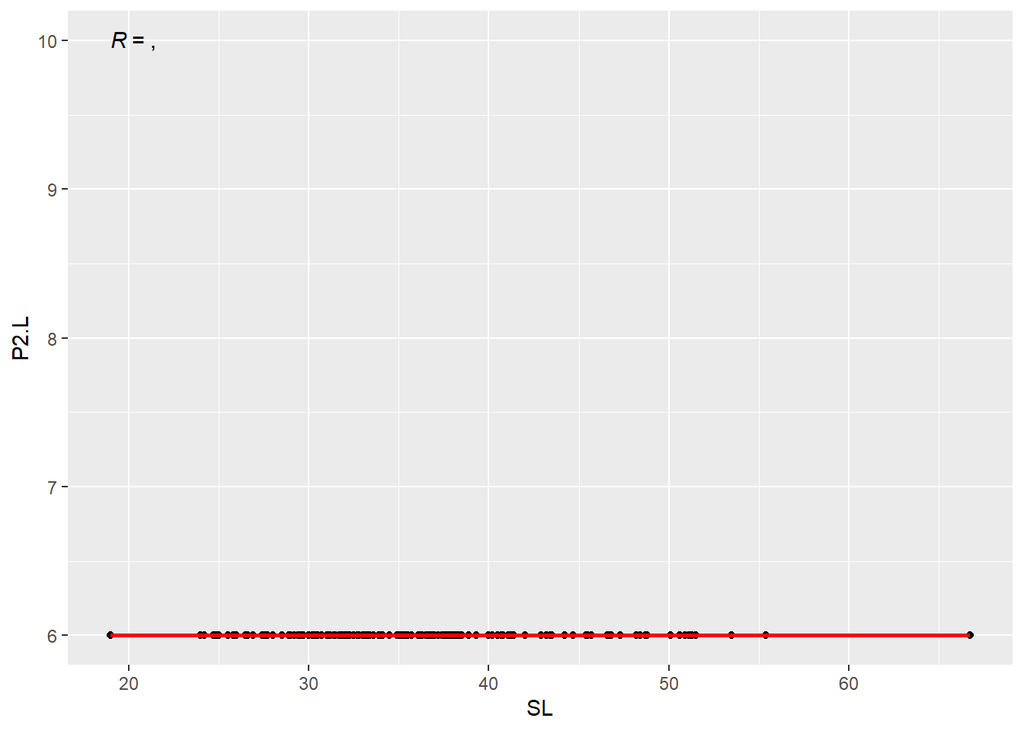

```r
reg.form.P2.L <- lm(form1$P2.L ~ form1$SL)
sd.form.P2.L <- rstandard(reg.form.P2.L)
reg.form.P2.L.plot <- ggplot(form1, aes(x = SL, y = P2.L)) +
  geom_point() +
  stat_smooth(method = "lm", col = "red") +
  stat_cor(label.y = 10)
reg.form.P2.L.plot
```

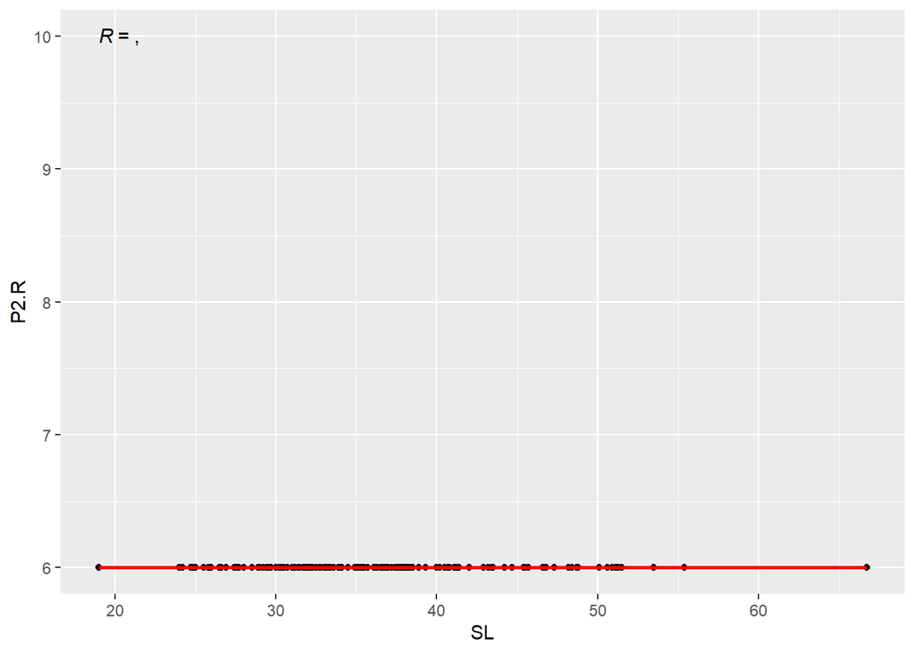

```r
reg.form.P2.R <- lm(form1$P2.R ~ form1$SL)
sd.form.P2.R <- rstandard(reg.form.P2.R)
reg.form.P2.R.plot <- ggplot(form1, aes(x = SL, y = P2.R)) +
  geom_point() +
  stat_smooth(method = "lm", col = "red") +
  stat_cor(label.y = 10)
reg.form.P2.R.plot
```

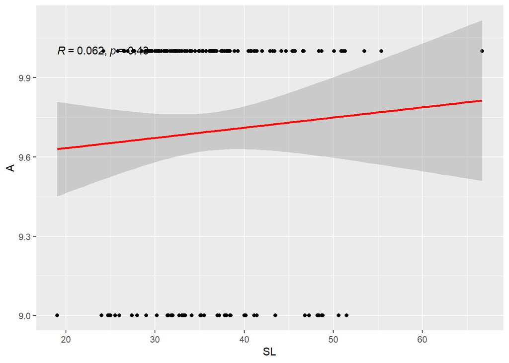

```r
reg.form.A <- lm(form1$A ~ form1$SL)
sd.form.A <- rstandard(reg.form.A)
reg.form.A.plot <- ggplot(form1, aes(x = SL, y = A)) +
  geom_point() +
  stat_smooth(method = "lm", col = "red") +
  stat_cor(label.y = 10)
reg.form.A.plot
```

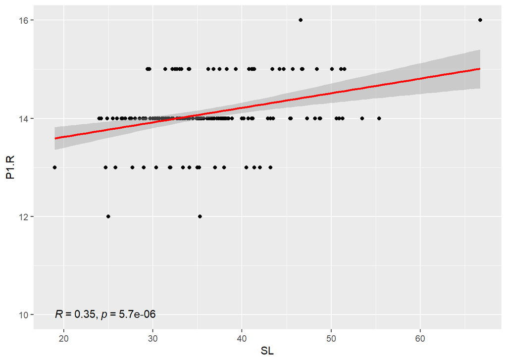

```r
reg.form.P1.R <- lm(form1$P1.R ~ form1$SL)
sd.form.P1.R <- rstandard(reg.form.P1.R)
reg.form.P1.R.plot <- ggplot(form1, aes(x = SL, y = P1.R)) +
  geom_point() +
  stat_smooth(method = "lm", col = "red") +
  stat_cor(label.y = 10)
reg.form.P1.R.plot
```

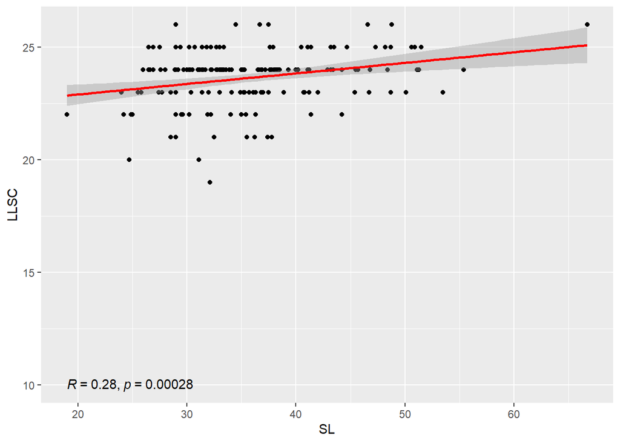

```r
reg.form.LLSC <- lm(form1$LLSC ~ form1$SL)
sd.form.LLSC <- rstandard(reg.form.LLSC)
reg.form.LLSC.plot <- ggplot(form1, aes(x = SL, y = LLSC)) +
  geom_point() +
  stat_smooth(method = "lm", col = "red") +
  stat_cor(label.y = 10)
reg.form.LLSC.plot
```

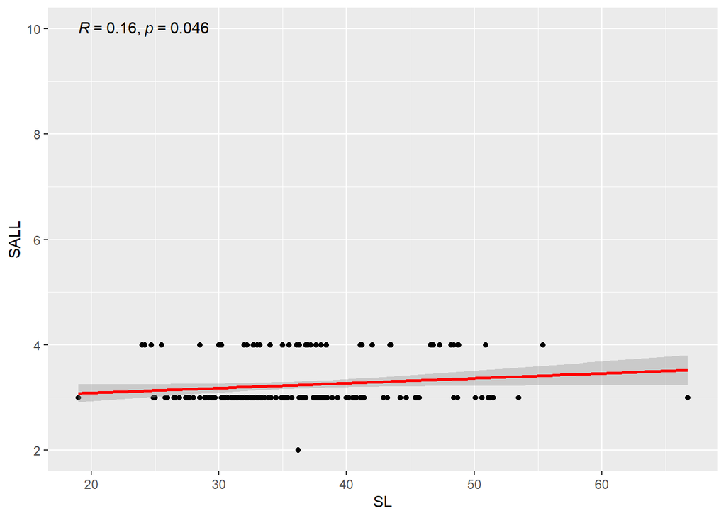

```r
reg.form.SALL <- lm(form1$SALL ~ form1$SL)
sd.form.SALL <- rstandard(reg.form.SALL)
reg.form.SALL.plot <- ggplot(form1, aes(x = SL, y = SALL)) +
  geom_point() +
  stat_smooth(method = "lm", col = "red") +
  stat_cor(label.y = 10)
reg.form.SALL.plot
```

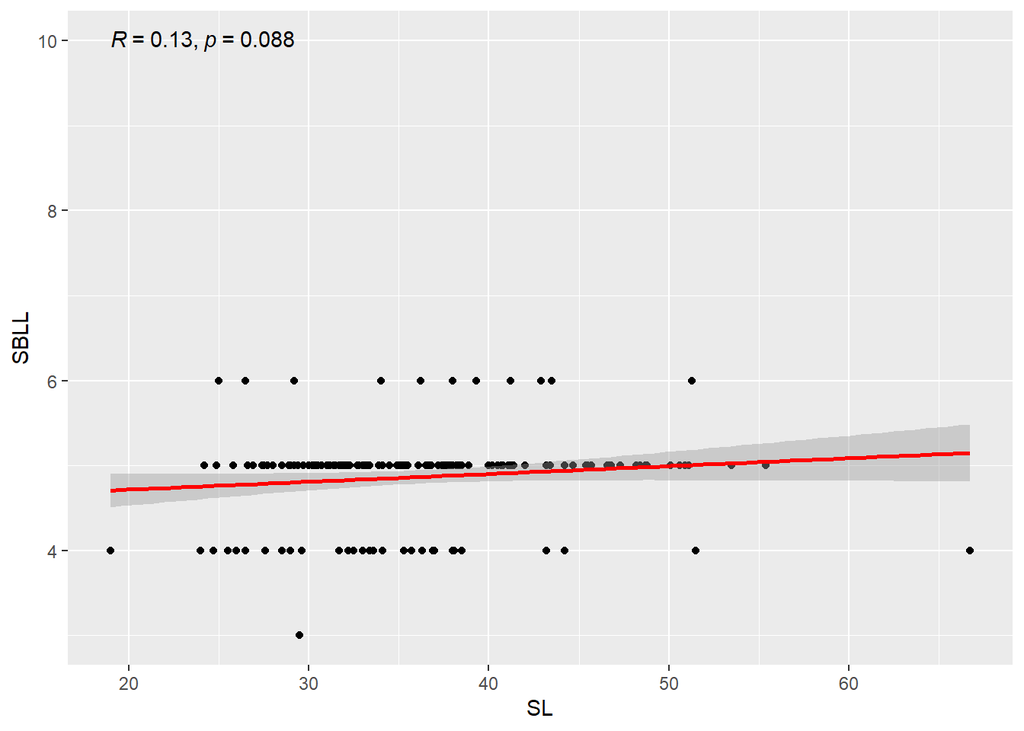

```r
reg.form.SBLL <- lm(form1$SBLL ~ form1$SL)
sd.form.SBLL <- rstandard(reg.form.SBLL)
reg.form.SBLL.plot <- ggplot(form1, aes(x = SL, y = SBLL)) +
  geom_point() +
  stat_smooth(method = "lm", col = "red") +
  stat_cor(label.y = 10)
reg.form.SBLL.plot
```

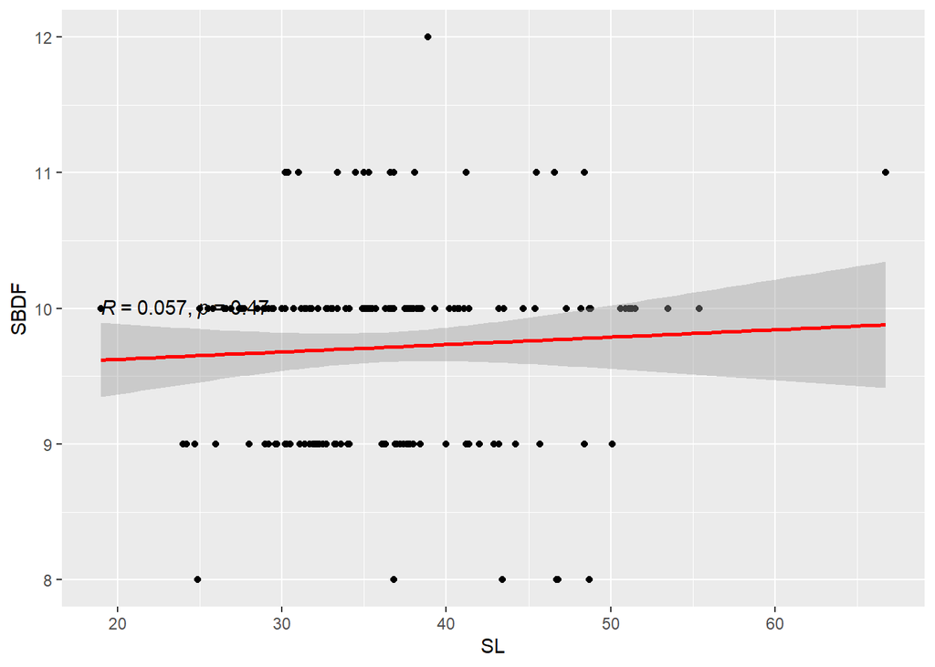

```r
reg.form.SBDF <- lm(form1$SBDF ~ form1$SL)
sd.form.SBDF <- rstandard(reg.form.SBDF)
reg.form.SBDF.plot <- ggplot(form1, aes(x = SL, y = SBDF)) +
  geom_point() +
  stat_smooth(method = "lm", col = "red") +
  stat_cor(label.y = 10)
reg.form.SBDF.plot
```